# Week 2 Assignment

pjsio

Wednesday, June 10, 2015

Echo shows the code results = false hides the results of that code

## Loading and Preprocessing the Data.

1. Load the csv file to R:

```r
a <- read.csv('D://Dropbox/JHU/5_Reproducible/week2/repdata-data-activity/activity.csv',
              header = TRUE)
```

2. Use the ‘group_by’ and ‘summarise’ method in dplyr in order to group the data by day:

```r
library(dplyr)
bydate <- group_by(a, date)
byday <- summarise(bydate, steps_t = sum(steps, na.rm=T), # total number of steps taken by day
                   step_avg = mean(steps, na.rm=T),       # average steps taken by day
                   step_med = median(steps, na.rm=T),     # median steps taken by day
                   step_min = min(steps, na.rm=T),        # minimum steps taken by day
                   step_max = max(steps, na.rm=T))        # maximum steps taken by day
byday
```

```
## Source: local data frame [61 x 6]
##
##          date steps_t step_avg step_med step_min step_max
## 1  2012-10-01       0       NA       NA       NA       NA
## 2  2012-10-02     126  0.43750        0        0      117
## 3  2012-10-03   11352 39.41667        0        0      613
## 4  2012-10-04   12116 42.06944        0        0      547
## 5  2012-10-05   13294 46.15972        0        0      555
## 6  2012-10-06   15420 53.54167        0        0      526
## 7  2012-10-07   11015 38.24653        0        0      523
## 8  2012-10-08       0      NaN       NA       NA       NA
## 9  2012-10-09   12811 44.48264        0        0      748
## 10 2012-10-10    9900 34.37500        0        0      413
## ..        ...     ...      ...      ...      ...      ...
```

## What is the mean total number of steps taken per day?

For this part of the assignment, I ignore the missing values in the dataset.

1. Total number of steps taken per day can be displayed through steps_t:

```r
byday$steps_t
```

```
##  [1]     0   126 11352 12116 13294 15420 11015     0 12811  9900 10304
## [12] 17382 12426 15098 10139 15084 13452 10056 11829 10395  8821 13460
## [23]  8918  8355  2492  6778 10119 11458  5018  9819 15414     0 10600
## [34] 10571     0 10439  8334 12883  3219     0     0 12608 10765  7336
## [45]     0    41  5441 14339 15110  8841  4472 12787 20427 21194 14478
## [56] 11834 11162 13646 10183  7047     0
```

2. The difference between a histogram and a barplot is that while both show the frequency of a variable, histograms usually deal with continuous variables (that are cut off at set intervals). Barplots, on the other hand, use discrete variables. The following is a histogram of the total number of steps taken each day.

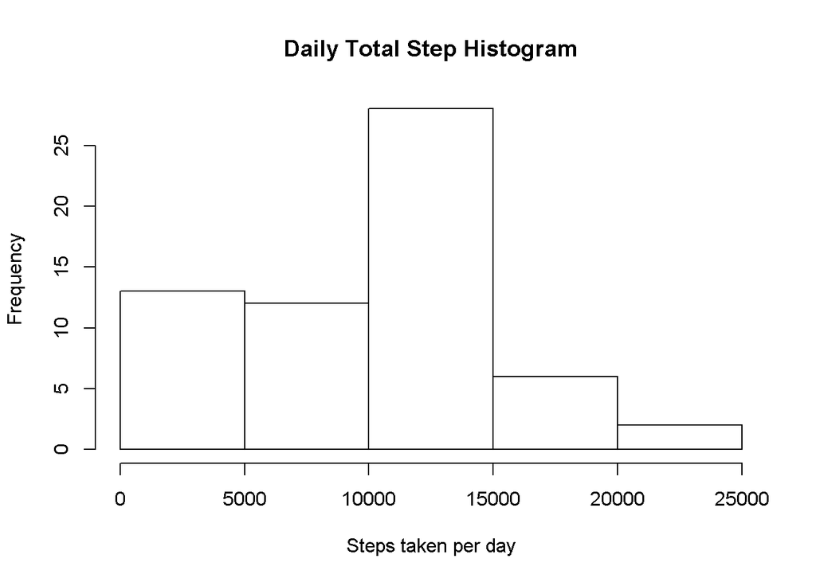

```r
hist(byday$steps_t, xlab='Steps taken per day', main = 'Daily Total Step Histogram')
```

3. The mean and median of the total number of steps taken per day are as follows:

```r
## Mean
mean(byday$steps_t)
```

```
## [1] 9354.23
```

```r
## Median
median(byday$steps_t)
```

```
## [1] 10395
```

## What is the average daily activity pattern?

```r
byinterval <- group_by(a, interval)
byinter <- summarise(byinterval, steps_tav = mean(steps, na.rm=T),
                     maxstep_intv = max(steps, na.rm=T))
byinterval <- mutate(byinterval, steps_tav = mean(steps, na.rm=T))
```

1. A time series plot (i.e. type = “l”) of the 5-minute interval (x-axis) and the average number of steps taken, averaged across all days (y-axis):

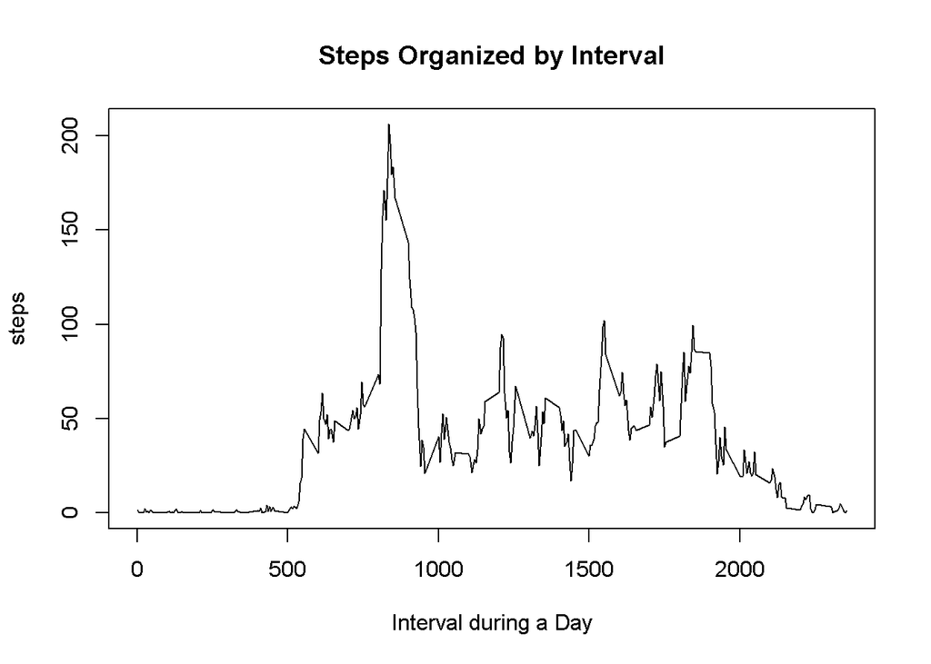

```r
plot(byinter$interval, byinter$steps_tav, type= 'l', ylab = 'steps', xlab = 'Interval during a Day', main='Steps Organized by Interval')
```

2. The 5-minute interval, on average across all the days in the dataset, that contains the maximum number of steps is as follows:

```r
filter(byinter, byinter$steps==max(byinter$steps)) ## the filter method in dplyr searches for
```

```
## Source: local data frame [1 x 3]
##
##   interval steps_tav maxstep_intv
## 1      835  206.1698          786
```

```r
                                                   ## the interval which matches the maximum step-value
```

## Imputing missing values

Note that there are a number of days/intervals where there are missing values (coded as NA). The presence of missing days may introduce bias into some calculations or summaries of the data.

```r
length(a$steps[a$steps == NA])
```

```
## [1] 17568
```

2. My strategy to filling in all of the missing values in the dataset is to use the mean for that 5-minute interval:
3. The following code fills in the missing values:

```r
newframe <- a
newframe$steps[is.na(a$steps)] <- byinterval$steps_tav[is.na(a$steps)] ## 1. Find the Missing Values
                                                                ## 2. Assign the interval-averages to those missing values
```

4. See the histogram of the total number of steps taken each day:

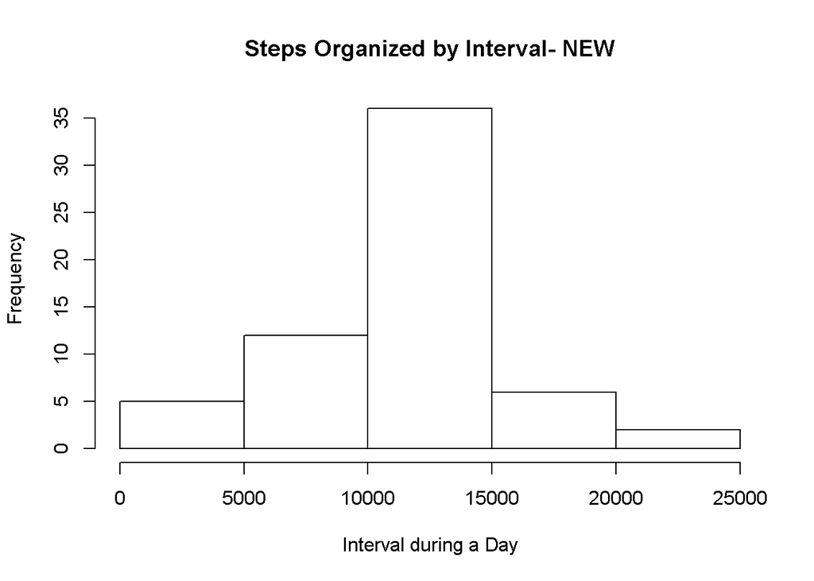

```r
new_bydate <- group_by(newframe, date)
new_byday <- summarise(new_bydate, steps_t = sum(steps, na.rm=T)) # total number of steps taken by day
hist(new_byday$steps_t, main = 'Steps Organized by Interval- NEW', xlab='Interval during a Day')
```

The mean and median total number of steps taken per day are as follows:

```r
mean(new_byday$steps_t) ## new mean
```

```
## [1] 10766.19
```

```r
median(new_byday$steps_t) ## new median
```

```
## [1] 10766.19
```

## Are there differences in activity patterns between weekdays and weekends?

```r
Sys.setlocale("LC_TIME","eng")
```

```
## [1] "English_United Kingdom.1252"
```

I create a new factor variable in the dataset with two levels Weekday and Weekend indicating whether a given date is a weekday or weekend day:

```r
daydata <- weekdays(as.POSIXct(newframe$date, tz='UTC'))
x<-c()
for (f in daydata) {
  if (f=='Saturday'|f=='Sunday'){
    x <- append(x, 'weekend')
  }
  else{
    x <- append(x, 'weekday')
  }
}
x <- as.factor(x)
newframe$TGIF <- x
```

I have created a panel plot containing a time series plot (i.e. type = “l”) of the 5-minute interval (x-axis) and the average number of steps taken, averaged across all weekday days or weekend days (y-axis).

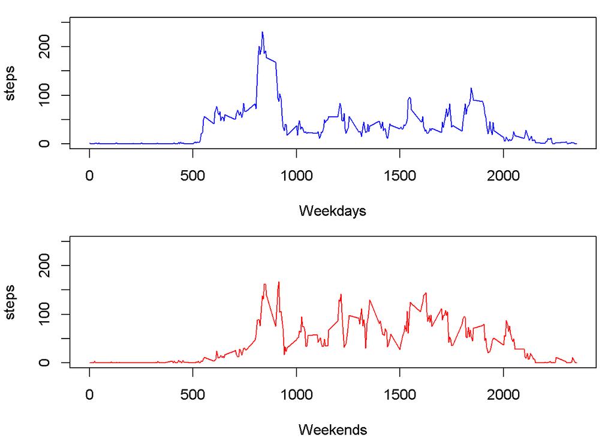

```r
weekday_f <- newframe[newframe$TGIF == 'weekday', ]
weekday_f_n <- group_by(weekday_f, interval)
weekday_f_n <- summarise(weekday_f_n, steps_tav = mean(steps, na.rm=T))

weekend_f <- newframe[newframe$TGIF == 'weekend', ]
weekend_f_n <- group_by(weekend_f, interval)
weekend_f_n <- summarise(weekend_f_n, steps_tav = mean(steps, na.rm=T))

par(mar = c(4,4,1,1), mfrow= c(2,1))
plot(weekday_f_n$interval, weekday_f_n$steps_tav, type = 'l', col = 'blue', ylim=c(0,250), xlab='Weekdays', ylab='steps')
plot(weekend_f_n$interval, weekend_f_n$steps_tav, type = 'l', col = 'red', ylim=c(0,250), xlab ='Weekends', ylab='steps')
```

The same plotting can be done with ggplot as well:

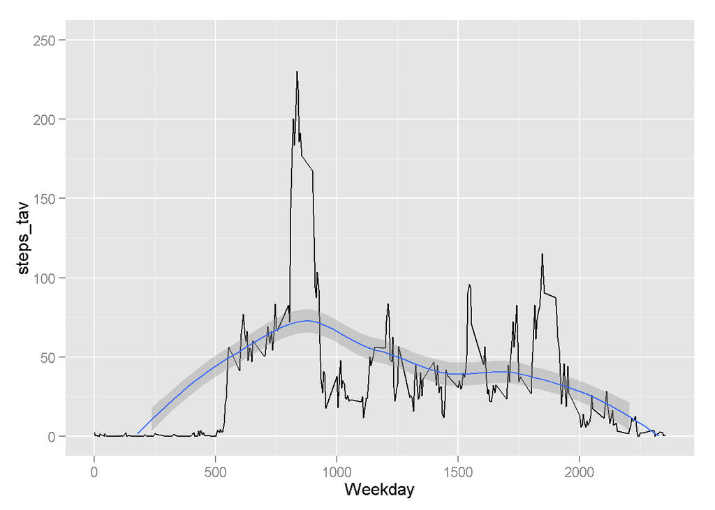

```r
library(ggplot2)

qplot(interval, steps_tav, data = weekday_f_n, geom = c('line', 'smooth'), xlab = 'Weekday', ylim=c(0,250))
```

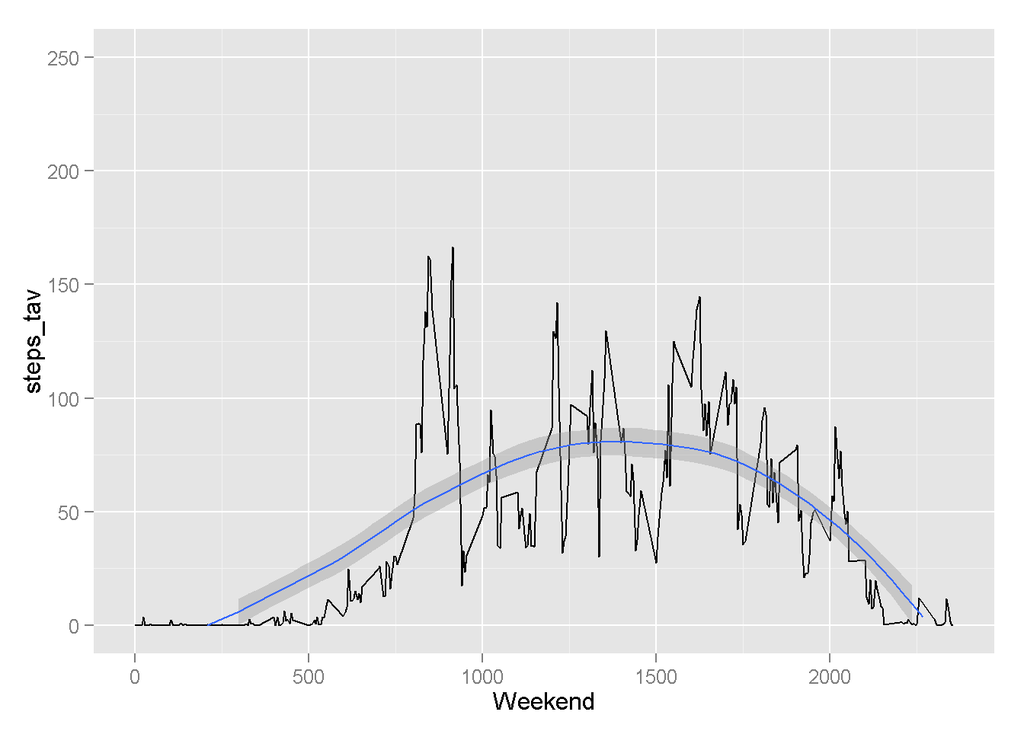

```r
qplot(interval, steps_tav, data = weekend_f_n, geom = c('line', 'smooth'), xlab='Weekend', ylim = (c(0,250)))
```

From the plots, we can find an interesting (and somewhat intuitive) observation: 1. Weekdays, compared to weekends, tend to have more workouts during the morning (presumably before work) 2. Weekends, compared to weekdays, tend to display a more evenly spread out workout routine throughout the day.

This may imply that the anonymized subject is occupied during the weekdays (presumably by full or part time employment).